# DS養成講座 Jリーグ観客動員数を予測せよ！

Shinji KAWASOE

Data : 2017-12-19

# 1 データの中を調べる。

データ探索を「Exploratory Data Analysis」と言うらしい。

# 2 データ加工

```r
## 使用ライブラリ
library(tidyverse)
library(modelr)
library(knitr)
```

```r
## データ読込(結合したデータ)
train<-read.csv("../data/transformed_train.csv", #読込ファイル
                header=TRUE, #読込データのヘッダー有無
                stringsAsFactors=FALSE #文字列の読込時の型指定(character)
)
```

# 3 収容率を対数オッズとして予測する

1. 目的変数を収容率に変換。$y_1$:観客動員数、capa:スタジアム収容人数として、

$y_2 = \frac{y_1}{capa}.$

2. 次に、対数オッズに変換する。

$y_3 = log(\frac{y_2}{1-y_2}).$

3. この$y_3$を線形回帰モデルを用いて予測する。このとこ、変数加工(変数作成、線形化など)やデータ 加工(欠損、外れ値処理)、変数選択(変数同士の相関確認)などを忘れないように。
4. 予測されて$\hat{y_3}$を収容率に戻します。このとき、対数オッズ変換の逆関数はロジスティク関数となる。

$\hat{y_2} = \frac{1}{1+e^{-\hat{y_3}}}.$

5. 最後に収容率から観客数に変換する。

$\hat{y_1} = capa * \hat{y_2}.$

```r
## 予測するy_3の作成
train <- train %>%
    dplyr::mutate(y_2 = y / capa,
                  y_3 = log(y_2 / (1 - y_2)))
## 収容率の範囲(0%より大きく、100%未満)
summary(train$y /train$capa)
```

```
##    Min. 1st Qu.  Median    Mean 3rd Qu.    Max.
## 0.05061 0.24649 0.38781 0.42090 0.57269 0.97900
```

# 4 外観

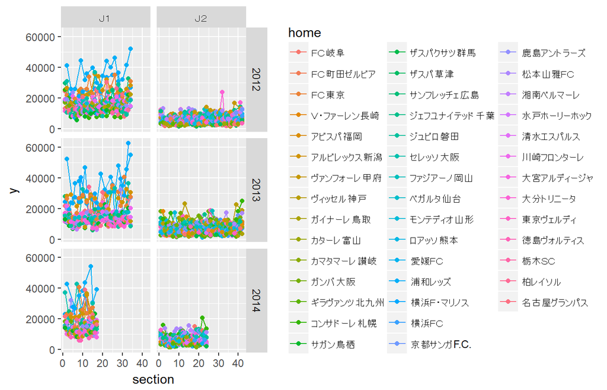

```r
ggplot(train, aes(section, y, colour = home)) +
    geom_line() +
    geom_point() +
    facet_grid(year ~ stage)
```

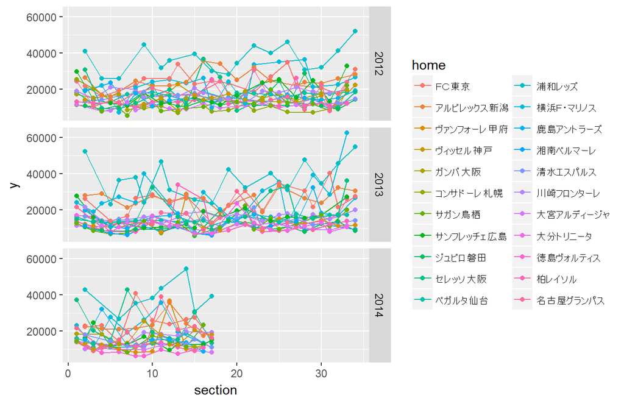

```r
train %>%
    dplyr::filter(stage == "Ｊ１") %>%
    ggplot(aes(section, y, colour = home)) +
    geom_line() +
    geom_point() +
    facet_grid(year ~ .)
```

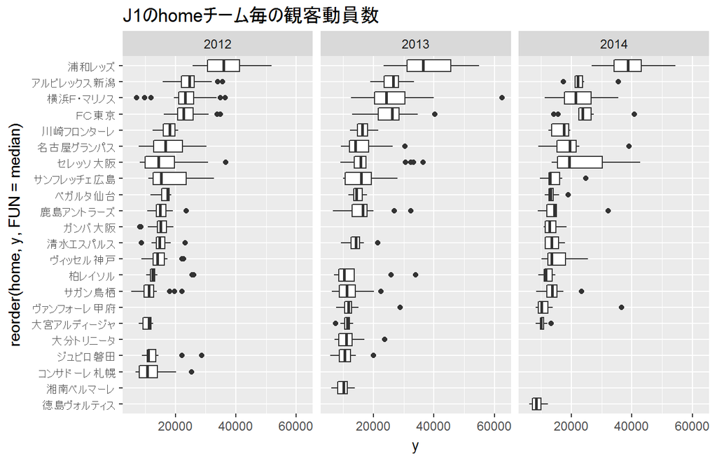

```r
train %>%
    dplyr::filter(stage == "Ｊ１") %>%
    ggplot(aes(x = reorder(home, y, FUN = median), y = y)) +
    geom_boxplot() +
    coord_flip() +
    ggtitle("J1のhomeチーム毎の観客動員数") +
    facet_grid(. ~ year)
```

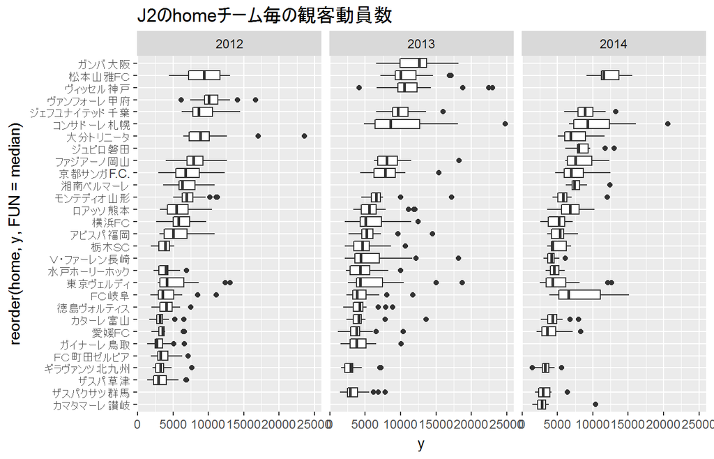

```r
train %>%
    dplyr::filter(stage != "Ｊ１") %>%
    ggplot(aes(x = reorder(home, y, FUN = median), y = y)) +
    geom_boxplot() +
    coord_flip() +
    ggtitle("J2のhomeチーム毎の観客動員数") +
    facet_grid(. ~ year)
```

# 5 Predictions and Residuals

stage, homeごとにモデルを作成する。

```r
## 予測に使う項目を選択
param = c("capa", "tv", "section")

lm_train<-dplyr::select(train, id, y, stage, home, param)

## stage毎にモデル作成
by_stage_train <- lm_train %>%
    group_by(stage, home) %>%
    nest()

####重回帰分析
### モデル構築
## family:目的変数の確率分布とリンク関数の設定(今回は正規分布と恒等写像)
stage_model <- function(df){
    glm(y ~ ., data=df, family=gaussian(link="identity"))
}

by_stage_train <- by_stage_train %>%
    mutate(model = map(data, stage_model))

by_stage_train <- by_stage_train %>%
    mutate(
        pred = map2(data, model, add_predictions),
        resids = map2(data, model, add_residuals)
    )

by_stage_train
```

```
## # A tibble: 51 x 6
##    stage               home              data     model              pred            resids
##    <chr>              <chr>            <list>    <list>            <list>            <list>
##  1  Ｊ１       ベガルタ仙台 <tibble [42 x 5]> <S3: glm> <tibble [42 x 6]> <tibble [42 x 6]>
##  2  Ｊ１   名古屋グランパス <tibble [43 x 5]> <S3: glm> <tibble [43 x 6]> <tibble [43 x 6]>
##  3  Ｊ１         ガンバ大阪 <tibble [25 x 5]> <S3: glm> <tibble [25 x 6]> <tibble [25 x 6]>
##  4  Ｊ１ サンフレッチェ広島 <tibble [43 x 5]> <S3: glm> <tibble [43 x 6]> <tibble [43 x 6]>
##  5  Ｊ１   コンサドーレ札幌 <tibble [17 x 5]> <S3: glm> <tibble [17 x 6]> <tibble [17 x 6]>
##  6  Ｊ１         サガン鳥栖 <tibble [42 x 5]> <S3: glm> <tibble [42 x 6]> <tibble [42 x 6]>
##  7  Ｊ１   川崎フロンターレ <tibble [43 x 5]> <S3: glm> <tibble [43 x 6]> <tibble [43 x 6]>
##  8  Ｊ１ 大宮アルディージャ <tibble [42 x 5]> <S3: glm> <tibble [42 x 6]> <tibble [42 x 6]>
##  9  Ｊ１         柏レイソル <tibble [43 x 5]> <S3: glm> <tibble [43 x 6]> <tibble [43 x 6]>
## 10  Ｊ１         浦和レッズ <tibble [42 x 5]> <S3: glm> <tibble [42 x 6]> <tibble [42 x 6]>
## # ... with 41 more rows
```

```r
resids <- unnest(by_stage_train, resids)
```

# 6 Residualの可視化

J1で更に確認すべきチーム

- FC東京
- 浦和レッズ
- 鹿島アントラーズ

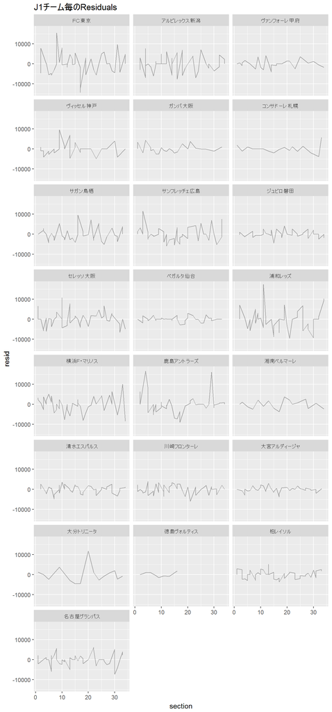

```r
resids %>%
    dplyr::filter(stage=="Ｊ１") %>%
    ggplot(aes(section, resid, group = home)) +
    geom_line(alpha = 1 / 3) +
    facet_wrap(~home, ncol=3) +
    ggtitle("J1チーム毎のResiduals")
```

J2で更に確認すべきチーム

- V・ファーレン長崎
- ヴィッセル神戸
- 東京ヴェルディ

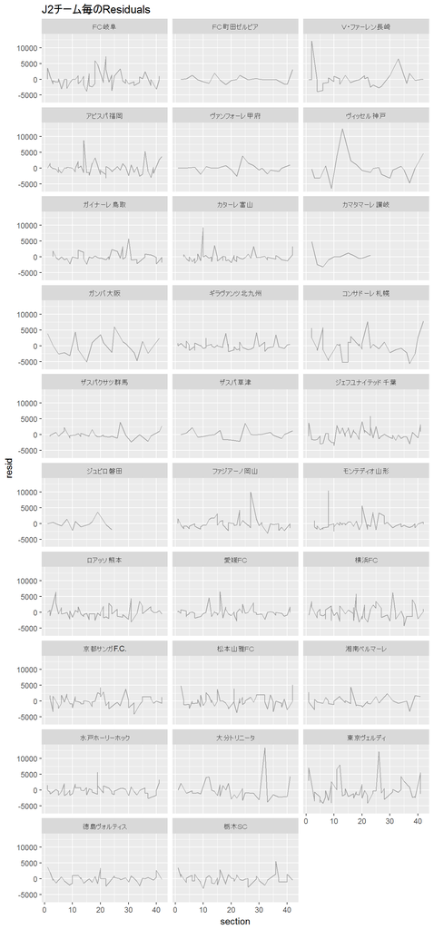

```r
resids %>%
    dplyr::filter(stage=="Ｊ２") %>%
    ggplot(aes(section, resid, group = home)) +
    geom_line(alpha = 1 / 3) +
    facet_wrap(~home, ncol=3) +
    ggtitle("J2チーム毎のResiduals")
```

# 7 broomを使う

未検討

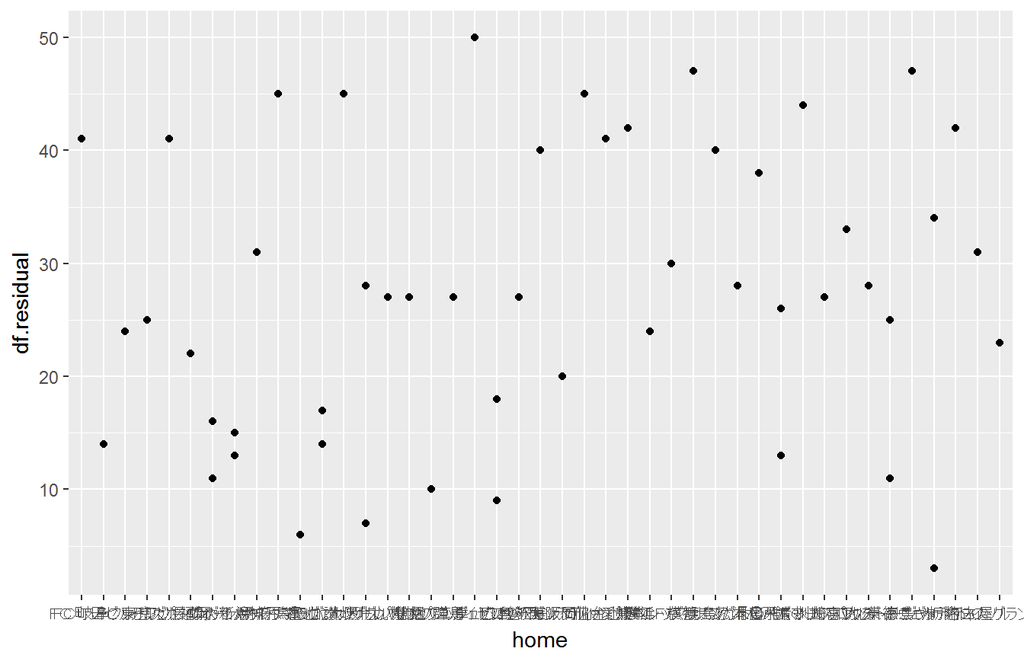

```r
glance <- by_stage_train %>%
    mutate(glance = map(model, broom::glance)) %>%
    unnest(glance, .drop=TRUE)

glance %>%
    ggplot(aes(home, df.residual)) +
    geom_point()
```